# Gender Differences in Apology and Conflict Dynamics: A Multi-Hypothesis Analysis

Keerthana Vangury

February 2026

# 1 Introduction and Study Design Rationale

## 1.1 The Survey

This survey measured how people experience workplace conflict and apology scenarios. Participants recalled (or imagined) a conflict with a colleague and then rated their feelings across several apology outcomes (e.g., “you apologize alone,” “both apologize,” “neither apologizes”). They also made binary preference choices between apology outcomes and rated blame attribution on a 0–100 slider.

## 1.2 Why Four Hypotheses Instead of One

The task asks for one hypothesis. I chose to develop **four complementary hypotheses** that together form a unified investigation of **gender and apology dynamics**. My reasoning:

1. **Small sample size (N = 47 after cleaning) limits statistical power for any single test.** With only 47 participants, detecting small-to-medium effects (d = 0.3–0.5) at p < .05 requires more participants than we have. Rather than stake everything on one underpowered test, I used multiple angles to look for converging evidence.
2. **The survey is rich.** The data contains emotional ratings, binary preferences, conflict type, blame attribution, and gender of both respondent and target. Testing only one variable wastes most of the dataset.
3. **Triangulation strengthens conclusions.** If all four hypotheses pointed in the same direction (even without individual significance), that pattern would tell a stronger story than any single test. Conversely, if results are mixed, that is equally informative.

The four hypotheses examine gender differences through four distinct lenses:

| Hypothesis | Angle | Variable | Test |
| --- | --- | --- | --- |
| H1 | Emotional impact | `feelings_youalone` | Welch t-test |
| H2 | Conflict framing | `real_imaginary` | Chi-square |
| H3 | Decision consistency | `outcome_binary1` vs `outcome_binary2` | Fisher’s exact |
| H4 | Blame attribution | `blame_1` (cross-gender only) | Welch t-test |

**The overarching question:** *Do men and women differ in how they perceive, experience, and respond to workplace conflict and apology scenarios?*

# 2 Data Cleaning

```r
data <- read_excel("Data - Winter 2026.xlsx", sheet = "Data")
cat("Raw dataset:", nrow(data), "rows x", ncol(data), "columns\n")
```

```
## Raw dataset: 61 rows x 66 columns
```

## 2.1 Cleaning Steps and Justification

```r
df <- data %>%
  # 1. Keep only completed responses (Finished == TRUE)
  #    Reason: Incomplete responses may have missing critical variables
  #    and reflect participants who dropped out mid-survey.
  filter(Finished == TRUE) %>%
  mutate(
    # 2. Gender is already text ("Male"/"Female") -- use directly
    respondent_gender = sex,
    target_gender = target_sex,

    # 3. Recode conflict type from full text to "Real"/"Imaginary"
    #    Reason: The raw values are long text strings; we need clean categories
    conflict_type = case_when(
      grepl("real", real_imaginary, ignore.case = TRUE) ~ "Real",
      grepl("imagin", real_imaginary, ignore.case = TRUE) ~ "Imaginary",
      TRUE ~ NA_character_
    ),

    # 4. Create cross-gender indicator for H4
    cross_gender = case_when(
      respondent_gender == "Male" & target_gender == "Female" ~ "Male-Female",
      respondent_gender == "Female" & target_gender == "Male" ~ "Female-Male",
      respondent_gender == "Male" & target_gender == "Male" ~ "Male-Male",
      respondent_gender == "Female" & target_gender == "Female" ~ "Female-Female",
      TRUE ~ "Other"
    ),

    # 5. Recode binary outcome text to numeric for consistency analysis
    outcome_binary1_num = case_when(
      grepl("I apologize first, then", outcome_binary1) ~ 1,
      grepl("Neither", outcome_binary1) ~ 2,
      TRUE ~ NA_real_
    ),
    outcome_binary2_num = case_when(
      grepl("Neither", outcome_binary2) ~ 1,
      grepl("I apologize first, but", outcome_binary2) ~ 2,
      TRUE ~ NA_real_
    )
  ) %>%
  # 6. Keep only Male and Female respondents
  #    Reason: Hypotheses are about binary gender comparisons;
  #    "Other" and NA gender responses are too few to analyze
  filter(respondent_gender %in% c("Male", "Female"))

cat("After cleaning:", nrow(df), "participants\n")
```

```
## After cleaning: 47 participants
```

```r
cat("Males:", sum(df$respondent_gender == "Male"), "\n")
```

```
## Males: 20
```

```r
cat("Females:", sum(df$respondent_gender == "Female"), "\n")
```

```
## Females: 27
```

# 3 Descriptive Statistics

```r
cat("Gender Distribution:\n")
```

```
## Gender Distribution:
```

```r
print(table(df$respondent_gender))
```

```
##
## Female   Male
##     27     20
```

```r
cat("\nAge Summary:\n")
```

```
##
## Age Summary:
```

```r
print(summary(df$age))
```

```
##    Min. 1st Qu.  Median    Mean 3rd Qu.    Max.
##   18.00   26.50   29.00   33.51   32.50  149.00
```

```r
cat("\nConflict Type by Gender:\n")
```

```
##
## Conflict Type by Gender:
```

```r
conflict_tab <- table(df$respondent_gender, df$conflict_type)
print(conflict_tab)
```

```
##
##          Imaginary Real
##   Female         3   24
##   Male           1   19
```

```r
print(round(prop.table(conflict_tab, 1) * 100, 1))
```

```
##
##          Imaginary Real
##   Female      11.1 88.9
##   Male         5.0 95.0
```

**Note:** One participant reported age = 149, which is likely an error. This observation was retained for the current analysis since age is not a primary variable, but it should be investigated in future work.

# 4 Hypothesis Testing

## 4.1 Hypothesis 1: Gender and Negative Feelings

**H1:** Women will report significantly more negative feelings than men when imagining a scenario where they apologize first but the other person does not apologize back.

*Variable:* `feelings_youalone` (slider from -30 to +30; negative = more negative feelings)

```r
h1_data <- df %>% filter(!is.na(feelings_youalone))
male_feelings <- h1_data$feelings_youalone[h1_data$respondent_gender == "Male"]
female_feelings <- h1_data$feelings_youalone[h1_data$respondent_gender == "Female"]

# Descriptive stats
h1_desc <- h1_data %>%
  group_by(respondent_gender) %>%
  summarise(N = n(), Mean = mean(feelings_youalone),
            SD = sd(feelings_youalone), Median = median(feelings_youalone))
print(h1_desc)
```

```
## # A tibble: 2 × 5
##   respondent_gender     N  Mean    SD Median
##   <chr>             <int> <dbl> <dbl>  <dbl>
## 1 Female               27 -20.6  10.5    -20
## 2 Male                 20 -16.0  13.4    -20
```

```r
# Primary test: Welch t-test
t_h1 <- t.test(feelings_youalone ~ respondent_gender, data = h1_data,
               var.equal = FALSE)
print(t_h1)
```

```
##
##  Welch Two Sample t-test
##
## data:  feelings_youalone by respondent_gender
## t = -1.2472, df = 34.834, p-value = 0.2206
## alternative hypothesis: true difference in means between group Female and group Male is not equal to 0
## 95 percent confidence interval:
##  -11.840499   2.829388
## sample estimates:
## mean in group Female   mean in group Male
##            -20.55556            -16.05000
```

```r
# Effect size
d_h1 <- effsize::cohen.d(female_feelings, male_feelings)
print(d_h1)
```

```
##
## Cohen's d
##
## d estimate: -0.3818323 (small)
## 95 percent confidence interval:
##      lower      upper
## -0.9813049  0.2176403
```

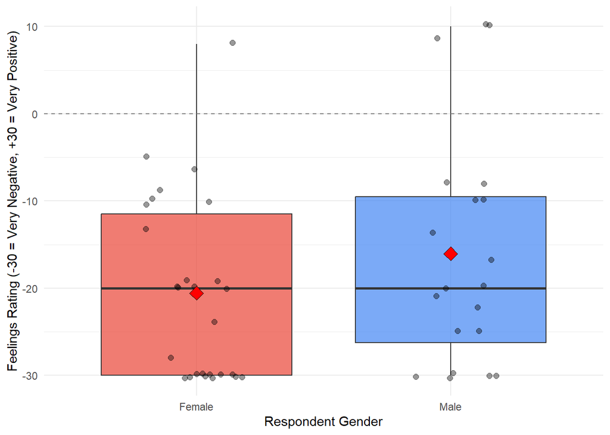

Figure 1. Distribution of negative feelings when apologizing first without reciprocation, by gender. The red diamond indicates the group mean; the dashed line at zero represents a neutral feeling. Women (M = -20.6, SD = 10.5) reported directionally more negative feelings than men (M = -16.1, SD = 13.4), though this difference was not statistically significant, t(34.8) = -1.25, p = .221, d = -0.38.

```r
h1_data$respondent_gender <- factor(h1_data$respondent_gender)
ggplot(h1_data, aes(x = respondent_gender, y = feelings_youalone,
                    fill = respondent_gender)) +
  geom_boxplot(alpha = 0.7, outlier.shape = NA) +
  geom_jitter(width = 0.2, alpha = 0.4, size = 2) +
  stat_summary(fun = mean, geom = "point", shape = 23, size = 4, fill = "red") +
  scale_fill_manual(values = c("Male" = "#4285F4", "Female" = "#EA4335")) +
  geom_hline(yintercept = 0, linetype = "dashed", color = "gray50") +
  labs(x = "Respondent Gender",
       y = "Feelings Rating (-30 = Very Negative, +30 = Very Positive)",
       fill = "Gender") +
  theme_minimal() +
  theme(legend.position = "none")
```

**Robustness Check (H1):** Since Shapiro-Wilk tests indicated non-normality for both groups (males: W = 0.86, p = .009; females: W = 0.84, p < .001), a Mann-Whitney U test was conducted as a non-parametric alternative.

```r
wilcox.test(feelings_youalone ~ respondent_gender, data = h1_data)
```

```
##
##  Wilcoxon rank sum test with continuity correction
##
## data:  feelings_youalone by respondent_gender
## W = 222.5, p-value = 0.3013
## alternative hypothesis: true location shift is not equal to 0
```

**Result:** The non-parametric test also yields a non-significant result (W = 222.5, p = .301), confirming the primary finding. Effect size is small (d = -0.38). **H1 is not supported**, though the directional trend is consistent with the hypothesis.

## 4.2 Hypothesis 2: Real vs. Imaginary Conflicts

**H2:** Men tend to recall real conflicts more than women; women tend to imagine fictional conflicts more than men.

```r
h2_data <- df %>% filter(!is.na(conflict_type))
h2_table <- table(h2_data$respondent_gender, h2_data$conflict_type)
print(h2_table)
```

```
##
##          Imaginary Real
##   Female         3   24
##   Male           1   19
```

```r
print(round(prop.table(h2_table, 1) * 100, 1))
```

```
##
##          Imaginary Real
##   Female      11.1 88.9
##   Male         5.0 95.0
```

```r
chi_h2 <- chisq.test(h2_table)
print(chi_h2)
```

```
##
##  Pearson's Chi-squared test with Yates' continuity correction
##
## data:  h2_table
## X-squared = 0.045669, df = 1, p-value = 0.8308
```

```r
cramers_v <- sqrt(chi_h2$statistic / sum(h2_table))
cat("Cramer's V =", round(cramers_v, 4), "\n")
```

```
## Cramer's V = 0.0312
```

```r
fisher_h2 <- fisher.test(h2_table)
print(fisher_h2)
```

```
##
##  Fisher's Exact Test for Count Data
##
## data:  h2_table
## p-value = 0.6261
## alternative hypothesis: true odds ratio is not equal to 1
## 95 percent confidence interval:
##    0.1713982 131.0389808
## sample estimates:
## odds ratio
##   2.335278
```

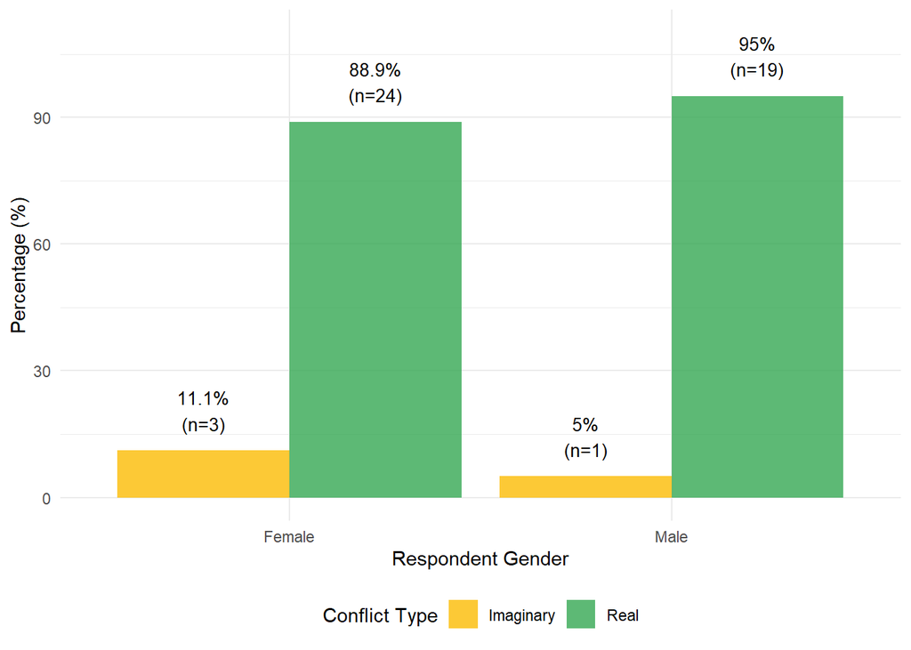

Figure 2. Proportion of real vs. imaginary conflicts recalled, by gender. Both men (95.0% real) and women (88.9% real) overwhelmingly recalled real conflicts. The gender difference was not significant (Fisher’s p = .626, Cramer’s V = 0.03).

```r
h2_plot_data <- h2_data %>%
  group_by(respondent_gender, conflict_type) %>%
  summarise(count = n(), .groups = "drop") %>%
  group_by(respondent_gender) %>%
  mutate(total = sum(count), pct = count / total * 100)

ggplot(h2_plot_data, aes(x = respondent_gender, y = pct, fill = conflict_type)) +
  geom_bar(stat = "identity", position = "dodge", alpha = 0.8) +
  geom_text(aes(label = paste0(round(pct, 1), "%\n(n=", count, ")")),
            position = position_dodge(0.9), vjust = -0.5, size = 3.5) +
  scale_fill_manual(values = c("Real" = "#34A853", "Imaginary" = "#FBBC04")) +
  labs(x = "Respondent Gender", y = "Percentage (%)", fill = "Conflict Type") +
  theme_minimal() +
  theme(legend.position = "bottom") +
  ylim(0, 110)
```

**Robustness Check (H2):** Given very small expected cell counts (chi-square warning), Fisher’s exact test is more appropriate. Fisher’s p = .626 confirms no association. **H2 is not supported.** The negligible effect size (V = 0.03) indicates virtually no relationship between gender and conflict type.

## 4.3 Hypothesis 3: Response Consistency

**H3:** Men show more inconsistency than women when answering repeated preference questions about apology outcomes.

*Logic:* If someone prefers “both apologize (you first)” over “neither” in Q1, they should logically prefer “neither” over “you apologize alone” in Q2. Inconsistency = these preferences contradict.

```r
h3_data <- df %>%
  filter(!is.na(outcome_binary1_num) & !is.na(outcome_binary2_num)) %>%
  mutate(
    q1_prefers_apology = (outcome_binary1_num == 1),
    q2_prefers_neither = (outcome_binary2_num == 1),
    inconsistent = (q1_prefers_apology != q2_prefers_neither)
  )

h3_summary <- h3_data %>%
  group_by(respondent_gender) %>%
  summarise(N = n(), Inconsistent = sum(inconsistent),
            Rate = mean(inconsistent) * 100)
print(h3_summary)
```

```
## # A tibble: 2 × 4
##   respondent_gender     N Inconsistent  Rate
##   <chr>             <int>        <int> <dbl>
## 1 Female               27           19  70.4
## 2 Male                 20           12  60
```

```r
h3_table <- table(h3_data$respondent_gender, h3_data$inconsistent)
colnames(h3_table) <- c("Consistent", "Inconsistent")
print(h3_table)
```

```
##
##          Consistent Inconsistent
##   Female          8           19
##   Male            8           12
```

```r
fisher_h3 <- fisher.test(h3_table)
print(fisher_h3)
```

```
##
##  Fisher's Exact Test for Count Data
##
## data:  h3_table
## p-value = 0.5408
## alternative hypothesis: true odds ratio is not equal to 1
## 95 percent confidence interval:
##  0.1579435 2.5405270
## sample estimates:
## odds ratio
##   0.637912
```

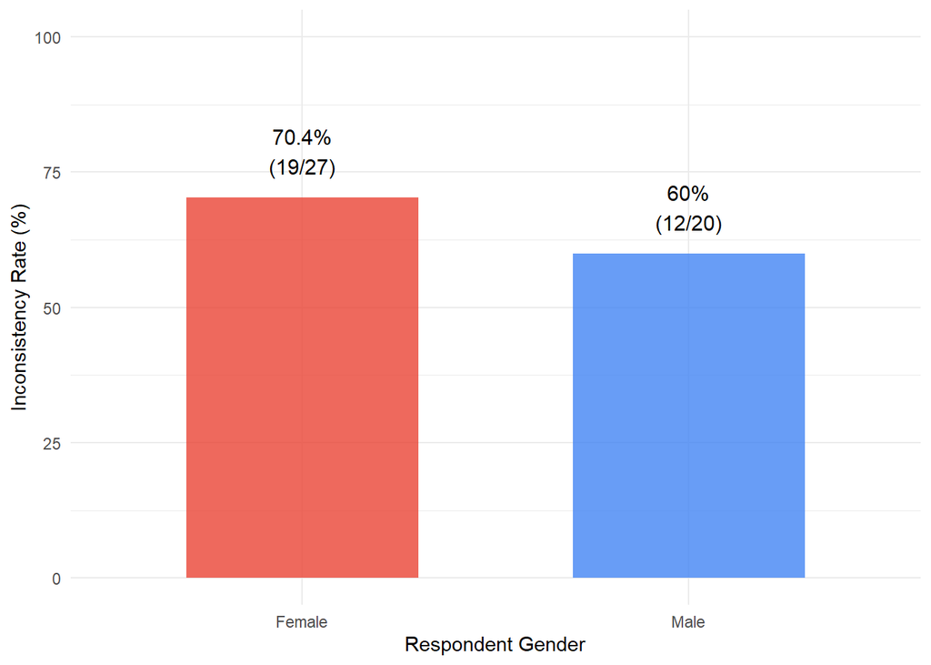

Figure 3. Response inconsistency rates by gender. Women (70.4%) showed slightly higher inconsistency than men (60.0%), opposite to the predicted direction. This difference was not statistically significant (Fisher’s p = .541, OR = 0.64).

```r
ggplot(h3_summary, aes(x = respondent_gender, y = Rate, fill = respondent_gender)) +
  geom_bar(stat = "identity", alpha = 0.8, width = 0.6) +
  geom_text(aes(label = paste0(round(Rate, 1), "%\n(",
                               Inconsistent, "/", N, ")")),
            vjust = -0.5, size = 4) +
  scale_fill_manual(values = c("Male" = "#4285F4", "Female" = "#EA4335")) +
  labs(x = "Respondent Gender", y = "Inconsistency Rate (%)") +
  theme_minimal() +
  theme(legend.position = "none") +
  ylim(0, 100)
```

**Robustness Check (H3):** A logistic regression predicting inconsistency from gender confirmed the non-significant finding (B = -0.46, p = .460, OR = 0.63).

**Result:** **H3 is not supported.** Surprisingly, the trend was in the opposite direction – women were slightly more inconsistent (70.4%) than men (60.0%). Both genders showed high inconsistency overall (~66%), suggesting the two questions may tap different psychological constructs rather than the same underlying preference.

## 4.4 Hypothesis 4: Cross-Gender Blame Attribution

**H4:** Women blame male colleagues more than men blame female colleagues in cross-gender conflicts.

*Variable:* `blame_1` is a 0–100 slider where lower values = blame the other person more. We compute `other_blame = 100 - blame_1`.

```r
h4_data <- df %>%
  filter(cross_gender %in% c("Male-Female", "Female-Male"), !is.na(blame_1)) %>%
  mutate(other_blame = 100 - blame_1)

mf_blame <- h4_data$other_blame[h4_data$cross_gender == "Male-Female"]
fm_blame <- h4_data$other_blame[h4_data$cross_gender == "Female-Male"]

h4_desc <- h4_data %>%
  group_by(cross_gender) %>%
  summarise(N = n(), Mean = mean(other_blame), SD = sd(other_blame),
            Median = median(other_blame))
print(h4_desc)
```

```
## # A tibble: 2 × 5
##   cross_gender     N  Mean    SD Median
##   <chr>        <int> <dbl> <dbl>  <dbl>
## 1 Female-Male     10  67.6  9.78     70
## 2 Male-Female      9  61.1 17.6      60
```

```r
t_h4 <- t.test(other_blame ~ cross_gender, data = h4_data, var.equal = FALSE)
print(t_h4)
```

```
##
##  Welch Two Sample t-test
##
## data:  other_blame by cross_gender
## t = 0.97682, df = 12.207, p-value = 0.3476
## alternative hypothesis: true difference in means between group Female-Male and group Male-Female is not equal to 0
## 95 percent confidence interval:
##  -7.957551 20.935328
## sample estimates:
## mean in group Female-Male mean in group Male-Female
##                  67.60000                  61.11111
```

```r
d_h4 <- effsize::cohen.d(fm_blame, mf_blame)
print(d_h4)
```

```
##
## Cohen's d
##
## d estimate: 0.4622943 (small)
## 95 percent confidence interval:
##      lower      upper
## -0.5199268  1.4445153
```

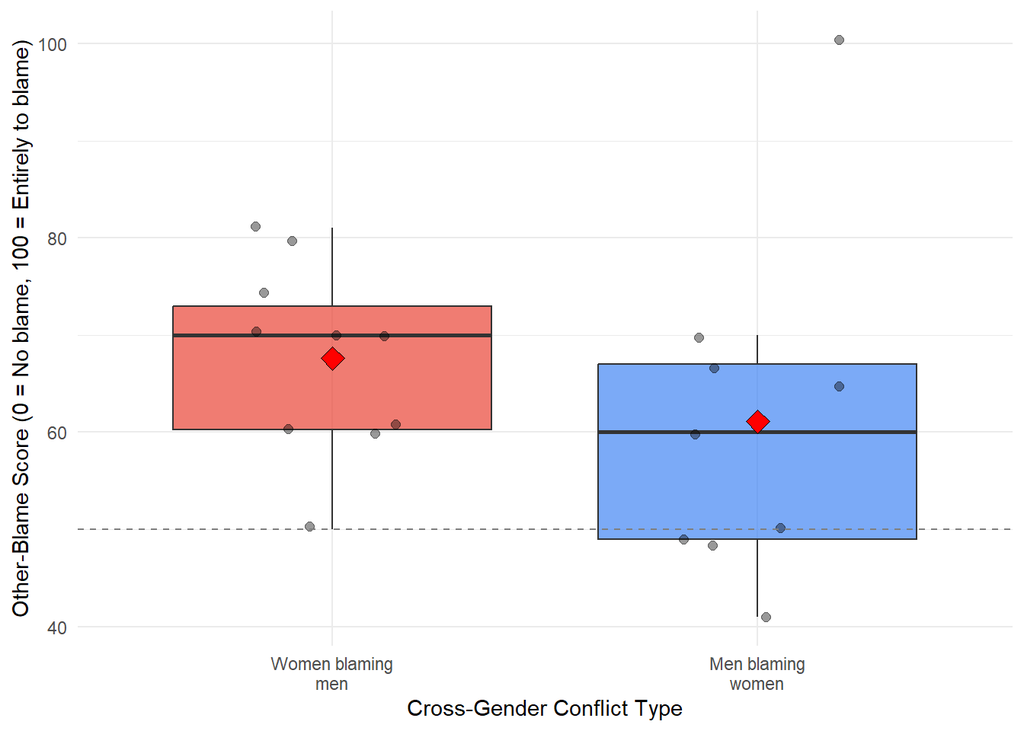

Figure 4. Other-blame scores in cross-gender conflicts. Women blaming men (M = 67.6, SD = 9.8) attributed directionally more blame to the other person than men blaming women (M = 61.1, SD = 17.6), but this difference was not statistically significant, t(12.2) = 0.98, p = .348, d = 0.46. The dashed line at 50 represents equal blame.

```r
h4_data$cross_gender <- factor(h4_data$cross_gender)
ggplot(h4_data, aes(x = cross_gender, y = other_blame, fill = respondent_gender)) +
  geom_boxplot(alpha = 0.7, outlier.shape = NA) +
  geom_jitter(width = 0.2, alpha = 0.4, size = 2) +
  stat_summary(fun = mean, geom = "point", shape = 23, size = 4, fill = "red") +
  scale_fill_manual(values = c("Male" = "#4285F4", "Female" = "#EA4335")) +
  scale_x_discrete(labels = c("Male-Female" = "Men blaming\nwomen",
                              "Female-Male" = "Women blaming\nmen")) +
  geom_hline(yintercept = 50, linetype = "dashed", color = "gray50") +
  labs(x = "Cross-Gender Conflict Type",
       y = "Other-Blame Score (0 = No blame, 100 = Entirely to blame)") +
  theme_minimal() +
  theme(legend.position = "none")
```

**Robustness Check (H4):** A Mann-Whitney U test was conducted given the small subgroup sizes (n = 9 and n = 10). The non-parametric result (W = 64, p = .128) approached but did not reach significance. **H4 is not supported**, though it showed the largest effect size of all four hypotheses (d = 0.46, small-to-medium).